# World Vector Choice

Jared Kibele

3/13/2019

I need to figure out which country dataset is better for joining up with sanitation data and the population data. The contestants are `regions_2017_update` and `gadm`. There are two main considerations:

1. Number of Country codes consistent with the sanitation data
2. Spatial overlap with population raster

## Country Codes

There are 233 in the sanitation data. I want to know how many of those countries are NOT represented in each of the vector candidates.

### Regions

a.k.a. `regions_2017_update`.

20 Countries in Sanitation but not in Regions

| COUNTRY, AREA OR TERRITORY | ISO3 |
| --- | --- |
| Aruba | ABW |
| Azerbaijan | AZE |
| Channel Islands | CHI |
| China, Hong Kong Special Administrative Region | HKG |
| China, Macao Special Administrative Region | MAC |
| Curaçao | CUW |
| Guadeloupe | GLP |
| Guam | GUM |
| Holy See | VAT |
| Isle of Man | IMN |
| Kazakhstan | KAZ |
| Lesotho | LSO |
| Martinique | MTQ |
| Puerto Rico | PRI |
| South Sudan | SSD |
| Swaziland | SWZ |
| Turkmenistan | TKM |
| United States Virgin Islands | VIR |
| West Bank and Gaza Strip | PSE |
| World | – |

### GADM

2 Countries in Sanitation but not in GADM

| COUNTRY, AREA OR TERRITORY | ISO3 |
| --- | --- |
| Channel Islands | CHI |
| World | – |

So far, the GADM is looking more promising, but now it’s time to look at…

## Spatial Overlap

1. Starting with the population raster, I’ll make a raster with the value 2 in every pixel where population density is > 0 and the value 0 elsewhere.
2. I’ll filter the vector layers to include only the polygons with a country code contained in the sanitation data.
3. I’ll make a raster from each of my vector layers (GADM and Regions) with 1s where there’s a polygon and 0s where there’s not.
4. Then I’ll add the pop based raster to each of the vector derived raster. Values of 3 will represent overlap, 1 will represent vector areas with no population, and 2s will represent population data without overlapping vector (in other words, population data that we can’t link to sanitation data).

### Simplified Population Raster

Create a raster with 2 in any cell with population density > 0, and 0 in all other cells. The setup is in R, but I’ll run the GDAL commands in a bash code block. I find these kinds of operations run far faster without the wrapper.

### Rasterize the Regions and Calculate

Check the projection of the regions shapefile:

```
## INFO: Open of `/home/shares/ohi/git-annex/land-based/wastewater/regions_2017_update/regions_2017_update.shp'
##       using driver `ESRI Shapefile' successful.
##
## Layer name: regions_2017_update
## Metadata:
##   DBF_DATE_LAST_UPDATE=2017-08-26
## Geometry: Polygon
## Feature Count: 526
## Extent: (-18040063.588075, -9020047.848074) - (18040076.181198, 9020047.848074)
## Layer SRS WKT:
## PROJCS["Mollweide",
##     GEOGCS["GCS_WGS_1984",
##         DATUM["WGS_1984",
##             SPHEROID["WGS_84",6378137,298.257223563]],
##         PRIMEM["Greenwich",0],
##         UNIT["Degree",0.017453292519943295]],
##     PROJECTION["Mollweide"],
##     PARAMETER["central_meridian",0],
##     PARAMETER["false_easting",0],
##     PARAMETER["false_northing",0],
##     UNIT["Meter",1]]
## type_w_ant: String (80.0)
## rgn_type: String (80.0)
## rgn_id: Integer (9.0)
## rgn_name: String (80.0)
## rgn_key: String (80.0)
## rgn_ant_id: Integer (9.0)
## area_km2: Real (24.15)
```

I want to keep everything in WGS84 (the projection of the population data) for now. So I’ll use OGR to reproject. Then I’ll subset and rasterize the reprojected vector layer.

Now do the band calc.

Now rasterize and calculate for the GADM.

### Results

First we’ll look at the GADM results and then at the Regions results.

#### GADM Results

The GADM ended up leaving 433689 that had no vector overlap. I’ll display the whole raster.

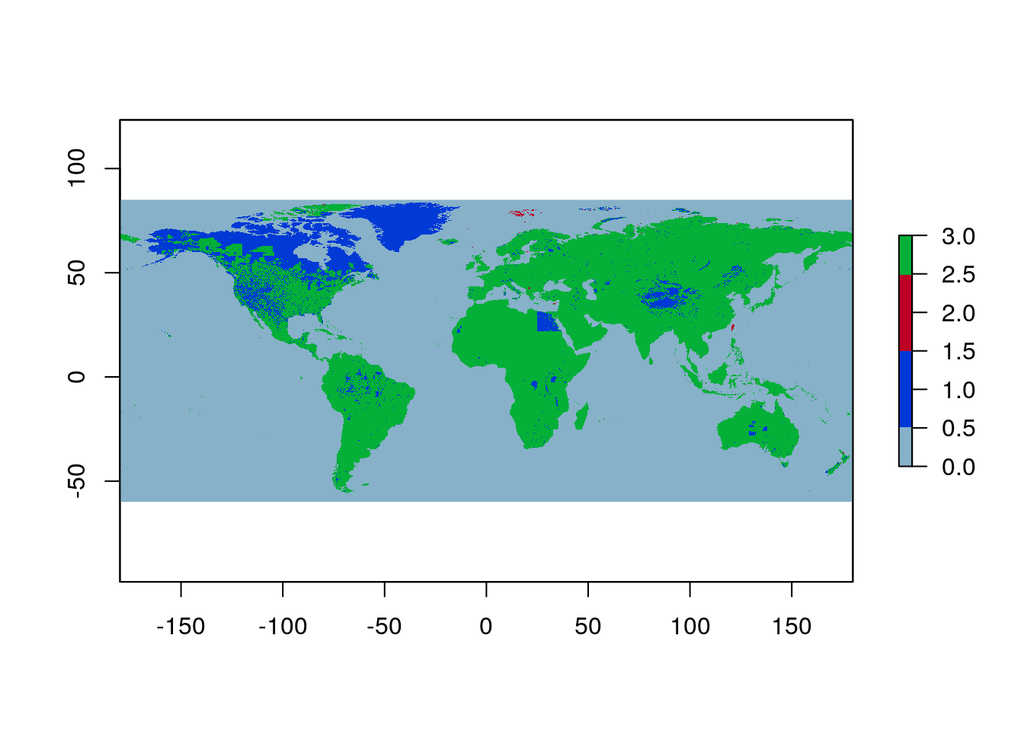

### Regions Results

Using the Regions (`regions_2017_update`), left us with 5,552,511 pixels of population uaccounted for. Here’s the whole raster.

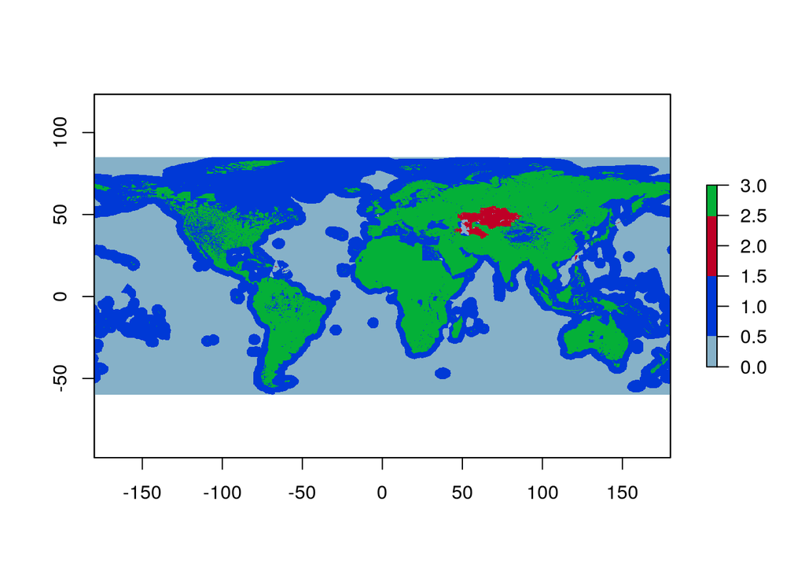